# Notes on how to use R Markdown

Sara Taheri

5/1/2017

## Markdown

Markdown is a text-to-HTML conversion tool for web writers. Markdown allows you to write using an easy-to-read, easy-to-write plain text format, then convert it to structurally valid XHTML (or HTML).

## R Markdown

R-Markdown is a flavor of markdown which allows R-users to embed R code into a markdown document. With R Markdown you can create HTML, PDF, and MS Word documents.

## How to create a R Markdown file

Click on the (+) sign on above left side of RStudio and choose “R Markdown …”

[figure not shown]

Write down the title of your document and choose one of the default output formats.

[figure not shown]

A template R Markdown document will be created. Save it on your computer and then click on **“Knit”** to generate your pdf (or html or MS Word).

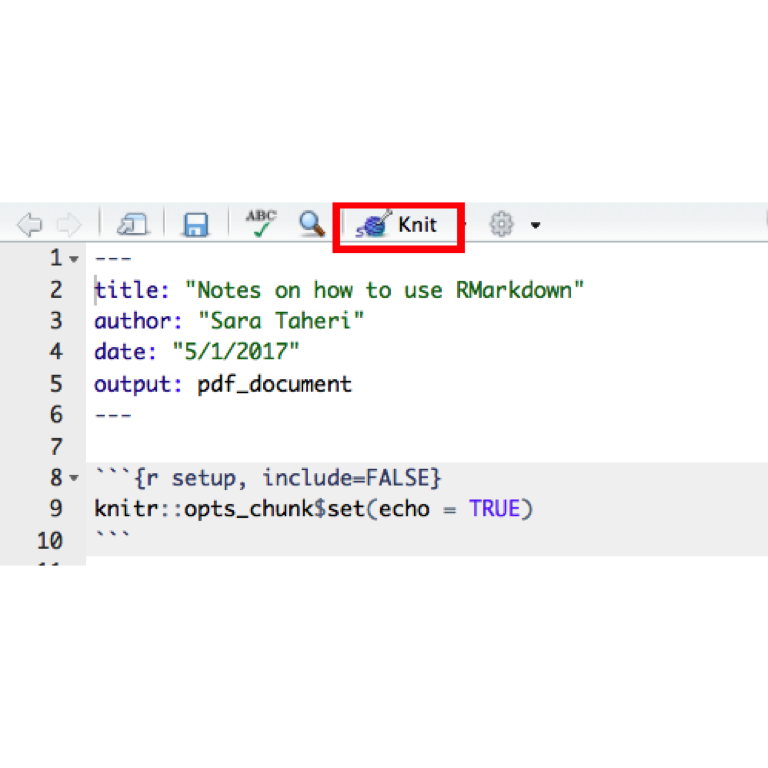

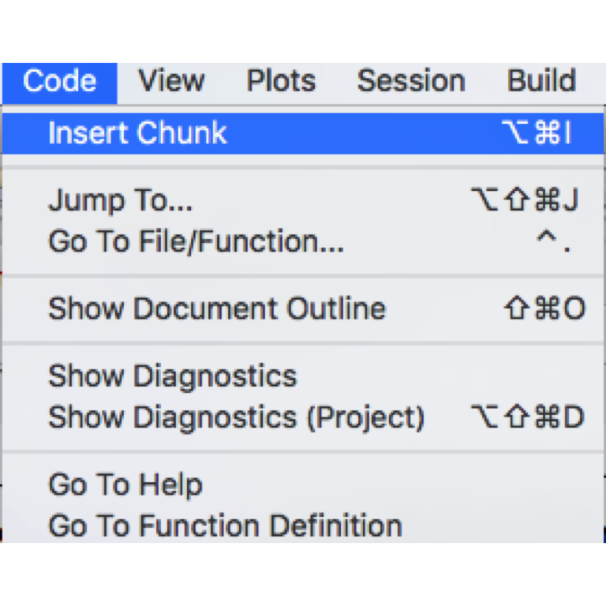

You can also create R chunk by writting your code between two lines that consist of three backtick in each line, like this:

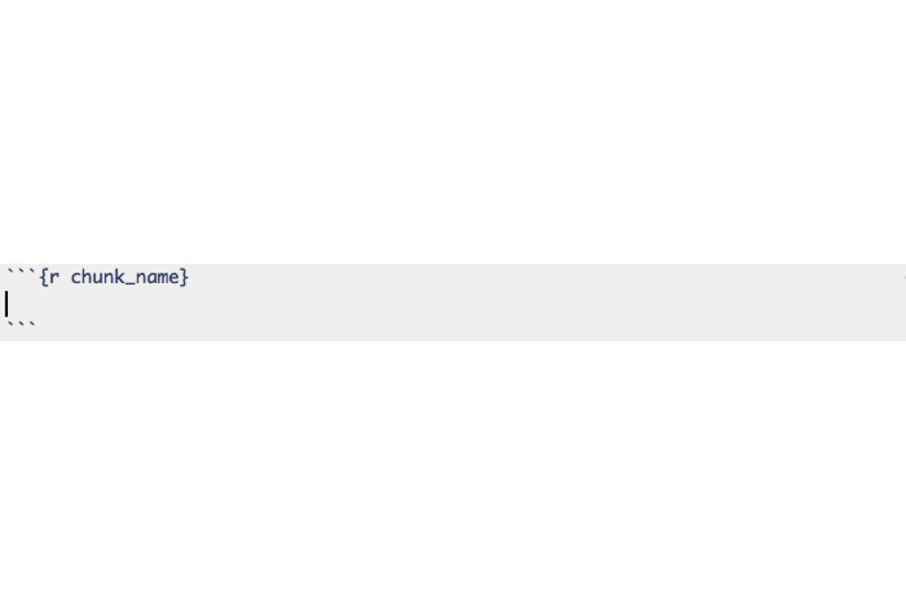

For example if I want to see the summary of an existing data set in R called “cars”, I have to simply type:

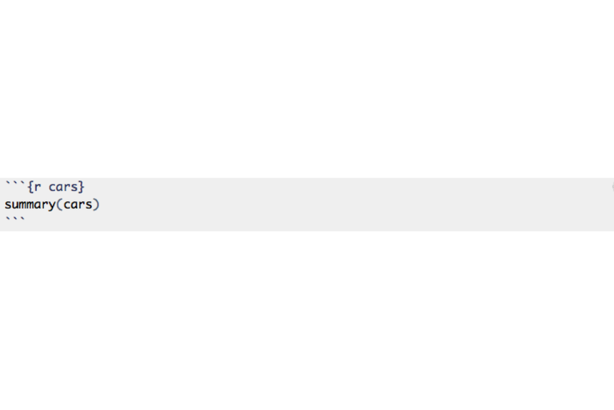

## Only display the result and hide codes

If you do not want to include the codes in the output of the file but you want to show the results of running the code, set `echo = FALSE`. This will prevent printing of the R code that generated the plot. You can also set the width and height of your plot like this:

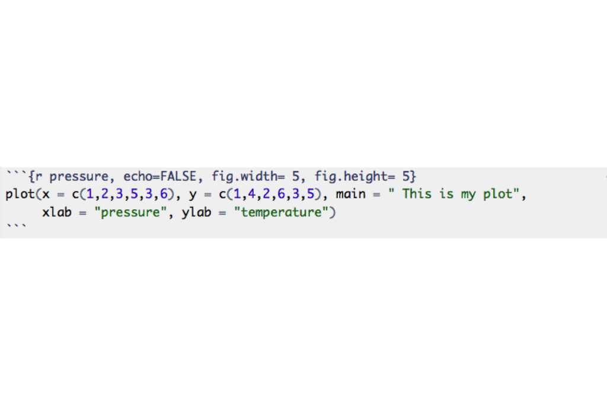

The result of this is as follows:

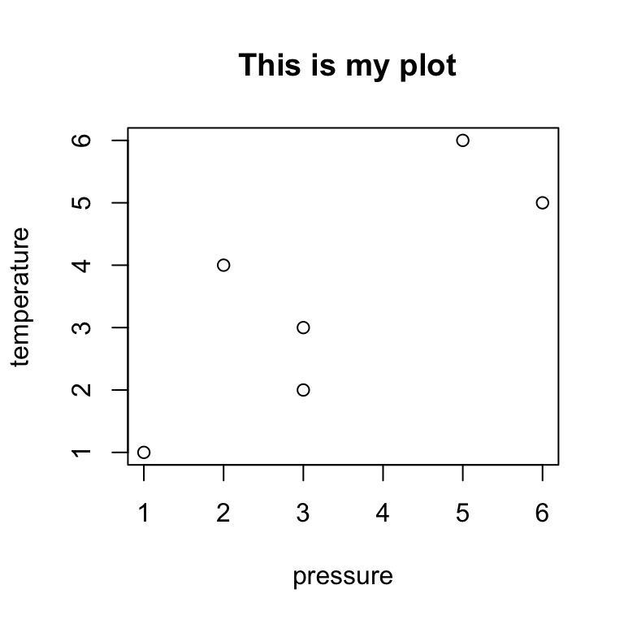

As you can see, in the result, no code is shown.

## Only display the codes and hide the results

If you want to hide the results and only show the code, you can write it like this:

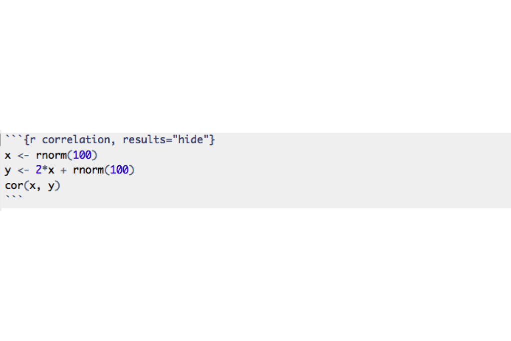

Here is the result of this:

```r
x <- rnorm(100)
y <- 2*x + rnorm(100)
cor(x, y)
```

You can see that the result of cor(x,y) is not produced.

## Add caption to your plot

If you want your plot to has a caption, you can add fig.cap=“my caption” to the arguments of your chunk, like this:

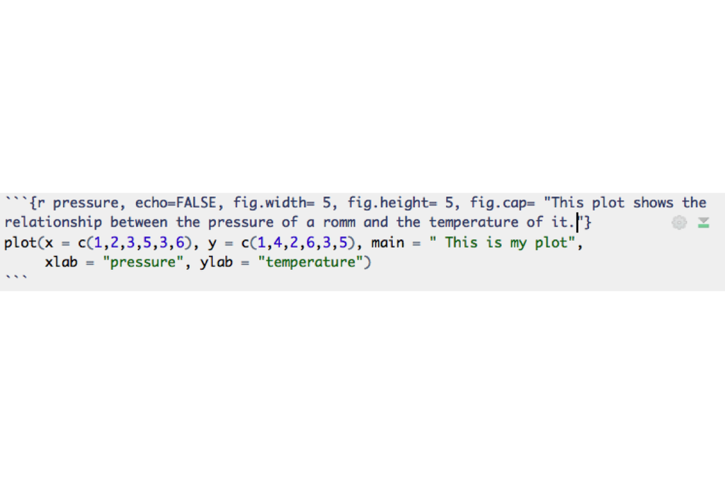

The result is in figure 1:

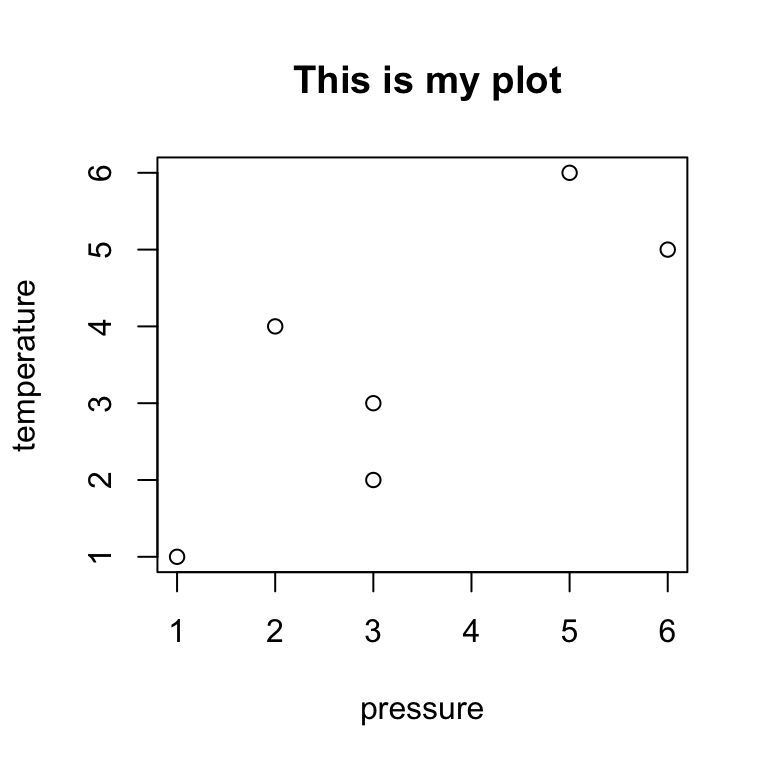

This plot shows the relationship between the pressure of a room and the temperature of it.

For more details on using R Markdown see [here](http://rmarkdown.rstudio.com). [Here](http://commonmark.org/help/tutorial/) is a step by step turorial that introduces single Makdown concepts at each step.

You can also create your posters with RMarkdown easily. [Here](https://github.com/odeleongt/flexdashboard-poster) you can find more information about it.